# Day 3: dimensionality reduction

```r
library(corrplot)
library(ggbiplot)
library(gridExtra)
library(dplyr)
library(ggplot2)
library(uwot)

# Our malaria dataset
df <- read.csv("../../data/Malaria_Dataset_DataViz.csv")

df$mtsi <- df$mosquito_temperature_suitability_index / 1000

cols_of_interest <- c(
  "itnuse0", "itnuse1", "itnuse2", "itnuse3",
  "act", "irs", "tasseled_cap_wetness", "mtsi",
  "precipitation", "enhanced_vegetation_index", "elevation", "nighttime_lights",
  "accessibility_tocity"
)

countries <- c("Sudan", "Zambia", "Nigeria")

set.seed(42)
```

# Exercise 1: correlation matrix

We have selected for you 13 columns of interest, and 3 different African countries from an economic, geographic, and demographic perspective: Sudan, Zambia, and Nigeria.

Make a correlation matrix using the features of interest then plot it.

Correlation matrix: `cor` from the `stats` package  
Correlation matrix plot: `corrplot` from the `corrplot` package

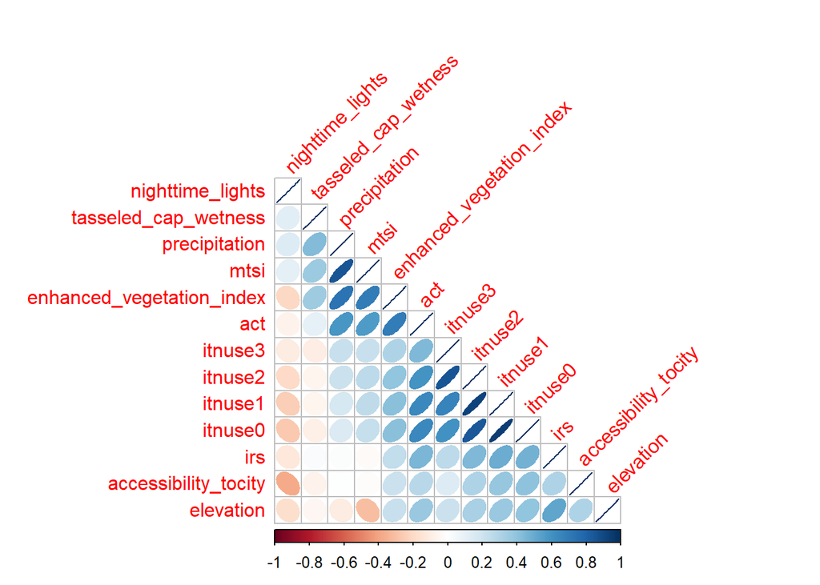

```r
sub_df <- df %>% filter(df$country %in% countries)

sub_df_cont <- sub_df %>%
  select(any_of(cols_of_interest))

# Correlation matrix
corr_matrix <- cor(sub_df_cont)

# Correlation matrix plot
corrplot(
  corr_matrix,
  # Only plot the lower triangular
  type = "lower",
  # Visualisation method: show ellipses
  # eccentricity scaled to the correlation value
  method = "ellipse",
  # Sort by angular order of the eigenvectors
  order = "AOE",
  # Rotate the text labels
  tl.srt = 45
)
```

# Exercise 2: PCA

1. Run a PCA on the subset of interest. Do not forget to scale and center the data!
2. Run a scree plot. How many components are worth retaining?

PCA: `prcomp` from the `stats` package  
Scree plot: `screeplot` from the `stats` package

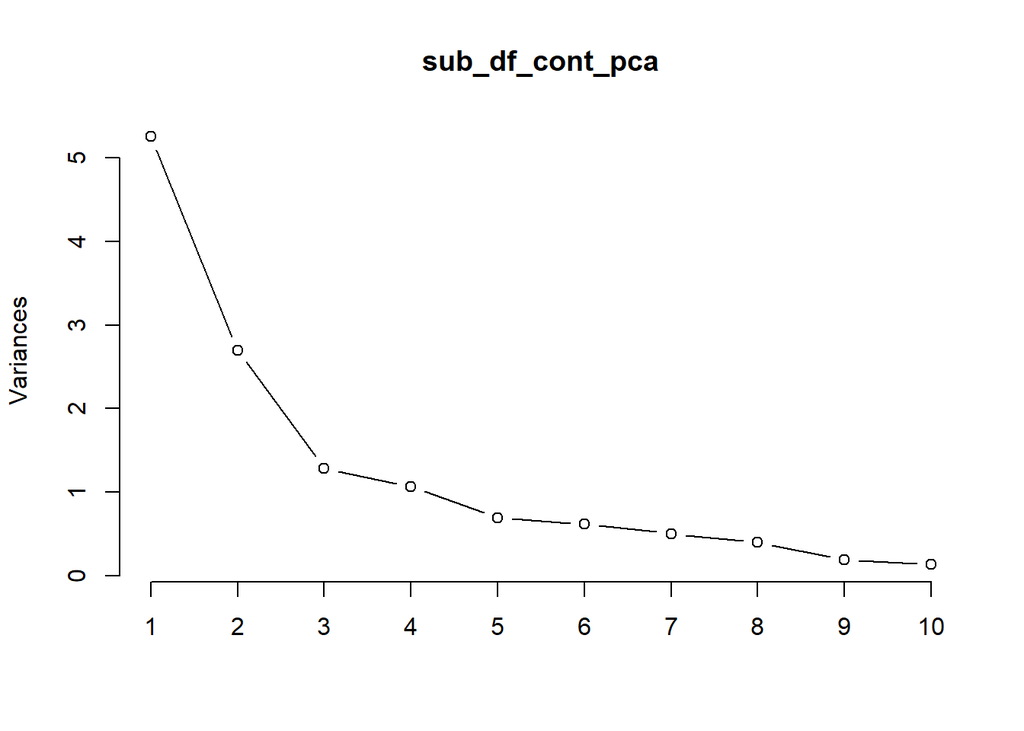

```r
sub_df_cont_pca <- prcomp(sub_df_cont, scale = TRUE, center = TRUE)

# Screeplot
screeplot(sub_df_cont_pca, type = "lines")
```

# Exercise 3: more PCA

Run a biplot to represent the information contained in the first two components.

1. Observe the arrows: what do the principle components capture?
2. Colour the biplot points by country: do the surveys cluster well by country? do the clusters make sense?
3. Colour the biplot points by PfPr

Biplot: `biplot` from the `stats` package or `ggbiplot` from the `ggbiplot` package

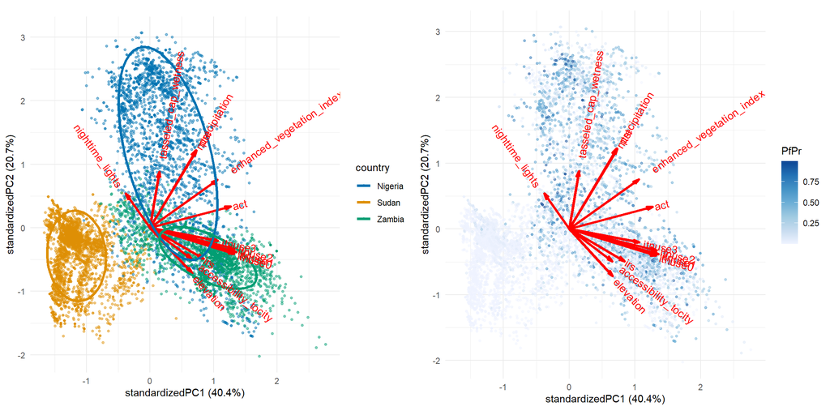

```r
fig1 <- ggbiplot(
  sub_df_cont_pca,
  # arrows: change colour and increase size
  varname.color = "red", varname.size = 4,
  # points: reduce size and increase transparency
  point.size = 1,
  alpha = 0.5,
  # colour by country
  groups = sub_df$country,
  # draw an ellipse (without fill colour)
  ellipse = TRUE,
  ellipse.fill = FALSE
) +
  # change country colour
  scale_color_manual(name = "country", values = colourblind[seq_along(countries)]) +
  # minimal theme
  theme_minimal()

fig2 <- ggbiplot(
  sub_df_cont_pca,
  # arrows: change colour and increase size
  varname.color = "red", varname.size = 4,
  # points: reduce size and increase transparency
  point.size = 1,
  alpha = 0.5,
  # colour by PfPr
  groups = sub_df$PfPr,
) +
  # change PfPr colour
  scale_color_distiller(name = "PfPr", palette = "Blues", direction = 1) +
  # minimal theme
  theme_minimal()

grid.arrange(fig1, fig2, ncol = 2)
```

# Exercise 4: UMAP

Let’s now turn to UMAP.

Perform 4 UMAP plots with 4 different values for `n_neighbors`: 2, 20, 200, 2000 (it should take ~ 5 min).

What do you notice? How do these visualisations compare to your PCA plot?

UMAP: `umap` (uwot) with `fast_sgd = TRUE`

```r
neigh_plots <- list()

neigh_numbs <- c(2, 20, 200, 2000)

for (i in seq_along(neigh_numbs)) {
  print(paste("Testing n_neighbors = ", neigh_numbs[[i]]), sep = "")
  sub_df_cont_umap <- uwot::umap(
    sub_df_cont,
    n_neighbors = neigh_numbs[[i]],
    fast_sgd = TRUE
  )

  neigh_plots[[i]] <- ggplot(
    as.data.frame(sub_df_cont_umap),
    aes(y = V2, x = V1, colour = sub_df$country)
  ) +
    geom_point() +
    scale_color_manual(name = "country", values = colourblind[seq_along(countries)])
}
```

```
## [1] "Testing n_neighbors =  2"
## [1] "Testing n_neighbors =  20"
## [1] "Testing n_neighbors =  200"
## [1] "Testing n_neighbors =  2000"
```

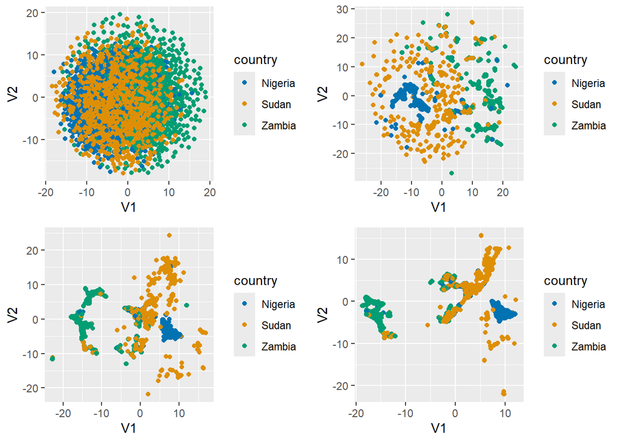

```r
do.call(grid.arrange, neigh_plots)
```